# Most Harmful Weather Events To Population Health With Greatest Economic Consequences

### Synopsis

This study aim is to identify which types of events are most harmful with respect to population health and which types of events have the greatest economic consequences.The analysis is based on the U.S. National Oceanic and Atmospheric Administration’s (NOAA) storm database and has concluded that storms and flood events can cause the most harmful public health and economics problems.

As summary:

- In health tornado has resulted the most harmful.
- Flood has resulted the most important event with economic consequences.

### Data Processing

The following libraris are been used in this study

```r
library(data.table)
library(ggplot2)
library(scales)
```

Downloading and loading the data from the source

```r
### get the url
fileUrl <- "https://d396qusza40orc.cloudfront.net/repdata%2Fdata%2FStormData.csv.bz2"
### check if the file exist
if (!file.exists("./data-StormData.csv.bz2")){
  download.file(fileUrl,destfile="./data-StormData.csv.bz2")
}
```

#### Reading data

The data has to be load from the file to the variable `raw_data`.

```r
### read data from the file
raw_data <- read.csv("data-StormData.csv.bz2", header=TRUE, na.strings="")
```

For simplify the dataset we proceed to select the relevant data

```r
### check the data structure
str(raw_data)
```

```
## 'data.frame':    902297 obs. of  37 variables:
##  $ STATE__   : num  1 1 1 1 1 1 1 1 1 1 ...
##  $ BGN_DATE  : Factor w/ 16335 levels "1/1/1966 0:00:00",..: 6523 6523 4242 11116 2224 2224 2260 383 3980 3980 ...
##  $ BGN_TIME  : Factor w/ 3608 levels "00:00:00 AM",..: 272 287 2705 1683 2584 3186 242 1683 3186 3186 ...
##  $ TIME_ZONE : Factor w/ 22 levels "ADT","AKS","AST",..: 7 7 7 7 7 7 7 7 7 7 ...
##  $ COUNTY    : num  97 3 57 89 43 77 9 123 125 57 ...
##  $ COUNTYNAME: Factor w/ 29600 levels "5NM E OF MACKINAC BRIDGE TO PRESQUE ISLE LT MI",..: 13512 1872 4597 10591 4371 10093 1972 23872 24417 4597 ...
##  $ STATE     : Factor w/ 72 levels "AK","AL","AM",..: 2 2 2 2 2 2 2 2 2 2 ...
##  $ EVTYPE    : Factor w/ 985 levels "   HIGH SURF ADVISORY",..: 834 834 834 834 834 834 834 834 834 834 ...
##  $ BGN_RANGE : num  0 0 0 0 0 0 0 0 0 0 ...
##  $ BGN_AZI   : Factor w/ 34 levels "  N"," NW","E",..: NA NA NA NA NA NA NA NA NA NA ...
##  $ BGN_LOCATI: Factor w/ 54428 levels " Christiansburg",..: NA NA NA NA NA NA NA NA NA NA ...
##  $ END_DATE  : Factor w/ 6662 levels "1/1/1993 0:00:00",..: NA NA NA NA NA NA NA NA NA NA ...
##  $ END_TIME  : Factor w/ 3646 levels " 0900CST"," 200CST",..: NA NA NA NA NA NA NA NA NA NA ...
##  $ COUNTY_END: num  0 0 0 0 0 0 0 0 0 0 ...
```

[output cut: 23 more lines]

```r
### select the relevant data
relevant_data <- raw_data[, c("BGN_DATE", "EVTYPE", "FATALITIES", "INJURIES",
                      "PROPDMG", "PROPDMGEXP", "CROPDMG", "CROPDMGEXP")]
```

The variable `BGN_DATE` need to be cast to date

```r
### cast to date
relevant_data$BGN_DATE <- as.Date(relevant_data$BGN_DATE, "%m/%d/%Y %H:%M:%S")
### check the data structure
str(relevant_data[, "BGN_DATE"])
```

```
##  Date[1:902297], format: "1950-04-18" "1950-04-18" "1951-02-20" "1951-06-08" ...
```

Once the data has been processed we perform a summary of the relevant columns and check for negatives and null values.

```r
### sumary data relevant information
summary(relevant_data)
```

```
##     BGN_DATE                        EVTYPE         FATALITIES
##  Min.   :1950-01-03   HAIL             :288661   Min.   :  0.0000
##  1st Qu.:1995-04-20   TSTM WIND        :219940   1st Qu.:  0.0000
##  Median :2002-03-18   THUNDERSTORM WIND: 82563   Median :  0.0000
##  Mean   :1998-12-27   TORNADO          : 60652   Mean   :  0.0168
##  3rd Qu.:2007-07-28   FLASH FLOOD      : 54277   3rd Qu.:  0.0000
##  Max.   :2011-11-30   FLOOD            : 25326   Max.   :583.0000
##                       (Other)          :170878
##     INJURIES            PROPDMG          PROPDMGEXP        CROPDMG
##  Min.   :   0.0000   Min.   :   0.00   K      :424665   Min.   :  0.000
##  1st Qu.:   0.0000   1st Qu.:   0.00   M      : 11330   1st Qu.:  0.000
##  Median :   0.0000   Median :   0.00   0      :   216   Median :  0.000
##  Mean   :   0.1557   Mean   :  12.06   B      :    40   Mean   :  1.527
##  3rd Qu.:   0.0000   3rd Qu.:   0.50   5      :    28   3rd Qu.:  0.000
##  Max.   :1700.0000   Max.   :5000.00   (Other):    84   Max.   :990.000
##                                        NA's   :465934
##    CROPDMGEXP
##  K      :281832
##  M      :  1994
##  k      :    21
##  0      :    19
##  B      :     9
##  (Other):     9
##  NA's   :618413
```

#### Analysis

1. Across the United States, which types of events are most harmful with respect to population health?

Fatalities and injuries are two mesurements that reflect the harmfulness of an event referenced to the population health. We subset and sum them in orderto find out the most harmful type of event.

```r
### subset and sum fatalities and injures
subset_fatalities <- aggregate(FATALITIES ~ EVTYPE, data = relevant_data, FUN = sum)
subset_injuries <- aggregate(INJURIES ~ EVTYPE, data = relevant_data, FUN = sum)
```

After susbest and process the data we are able to plot the fatalities and injures so we can identify the top 10 most harmful events.

```r
### order the data for fatalities and injuries
data_fatalities <- subset_fatalities[order(subset_fatalities$FATALITIES, decreasing = T), ]
data_injuries <- subset_injuries[order(subset_injuries$INJURIES, decreasing = T), ]
```

2. Across the United States, which types of events have the greatest economic consequences?

We need to change the cast of the values to `numeric` so we can properly plot them, following the code that help us to read the absolute value and the exponent: * H,h = hundreds = 100 * K,k = kilos = thousands = 1,000 * M,m = millions = 1,000,000 * B,b = billions = 1,000,000,000

For our porpouse we will plot our data in Millions so `millions = 1`:

```r
### create a new column with the proper value for B,M,K,H and others
relevant_data$PROPDMG[relevant_data$PROPDMGEXP %in% "B"] <-
      relevant_data$PROPDMG[relevant_data$PROPDMGEXP %in% "B"] * 10^3
relevant_data$PROPDMG[relevant_data$PROPDMGEXP %in% c("M", "m")] <-
      relevant_data$PROPDMG[relevant_data$PROPDMGEXP %in% c("M", "m")] * 1
relevant_data$PROPDMG[relevant_data$PROPDMGEXP %in% c("K")] <-
      relevant_data$PROPDMG[relevant_data$PROPDMGEXP %in% c("K")] * 10^(-3)
relevant_data$PROPDMG[relevant_data$PROPDMGEXP %in% c("H", "h")] <-
      relevant_data$PROPDMG[relevant_data$PROPDMGEXP %in% c("H", "h")] * 10^(-4)
relevant_data$PROPDMG[!(relevant_data$PROPDMGEXP %in% c("B", "M", "m", "K", "H", "h"))] <-
      relevant_data$PROPDMG[!(relevant_data$PROPDMGEXP %in% c("B", "M", "m", "K", "H", "h"))] * 10^(-6)

relevant_data$CROPDMG[relevant_data$CROPDMGEXP %in% "B"] <-
      relevant_data$CROPDMG[relevant_data$CROPDMGEXP %in% "B"] * 10^3
relevant_data$CROPDMG[relevant_data$CROPDMGEXP %in% c("M", "m")] <-
      relevant_data$CROPDMG[relevant_data$CROPDMGEXP %in% c("M", "m")] * 1
relevant_data$CROPDMG[relevant_data$CROPDMGEXP %in% c("K", "k")] <-
      relevant_data$CROPDMG[relevant_data$CROPDMGEXP %in% c("K", "k")] * 10^(-3)
relevant_data$CROPDMG[!(relevant_data$CROPDMGEXP %in% c("B", "M", "m", "K", "k"))] <-
      relevant_data$CROPDMG[!(relevant_data$CROPDMGEXP %in% c("B", "M", "m", "K", "k"))] * 10^(-6)
```

Finally we aggregate both property and crop damages and order the data to find the greatest economic consequences once ploted the Top 10.

```r
### both damages value
economical_damage <- relevant_data$PROPDMG + relevant_data$CROPDMG
### sum by type  to get the total
eco_dmg_total <- aggregate(economical_damage ~ relevant_data$EVTYPE, FUN = sum)
### order the data
eco_dmg_tot_ordered <- eco_dmg_total[order(eco_dmg_total$economical_damage, decreasing = T), ]
### add column name
names(eco_dmg_tot_ordered)[1] <- "evtype"
```

### Results

1. Across the United States, which types of events are most harmful with respect to population health?

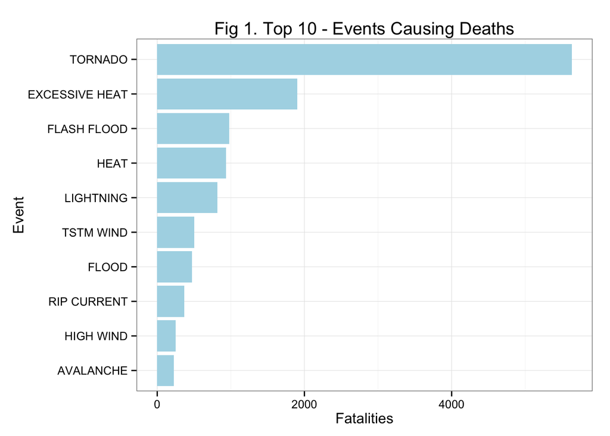

```r
### plot the top 10 fatalities data
ggplot(data_fatalities[1:10, ], aes(x = reorder(EVTYPE, FATALITIES), y = FATALITIES)) + theme_bw() +
    geom_bar(stat = "identity", fill = I("lightblue")) + coord_flip() +
    labs( title = "Fig 1. Top 10 - Events Causing Deaths", x = "Event", y = "Fatalities" )
```

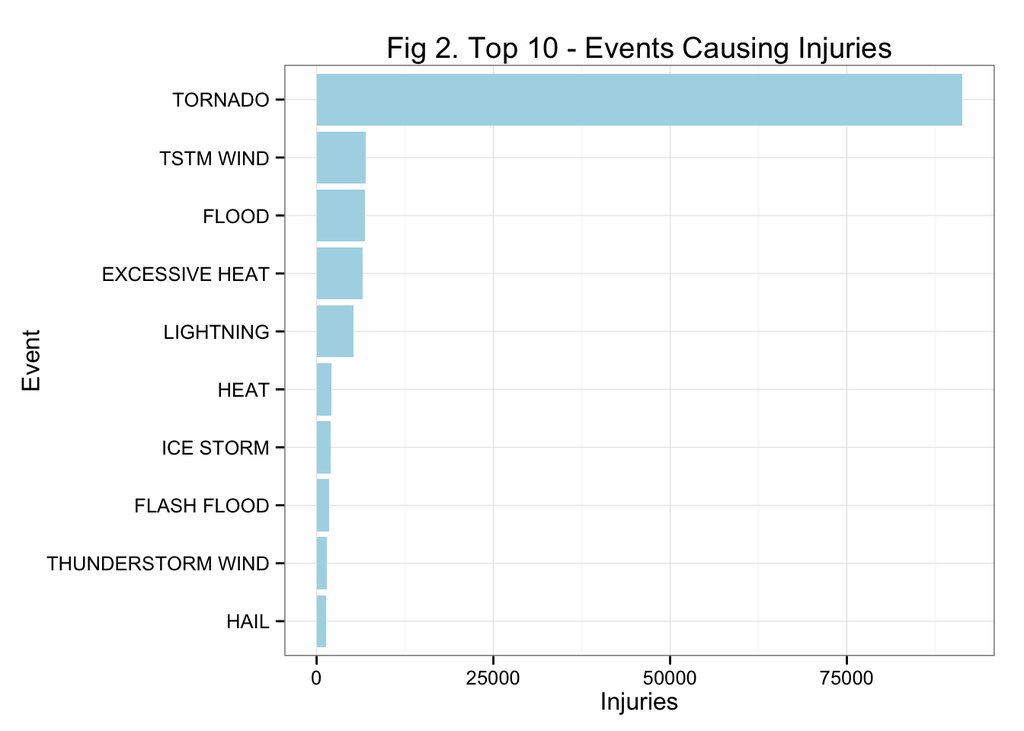

```r
### plot the top 10 injuries data
ggplot(data_injuries[1:10, ], aes(x = reorder(EVTYPE, INJURIES), y = INJURIES)) + theme_bw() +
    geom_bar(stat = "identity", fill = I("lightblue")) + coord_flip() +
    labs( title = "Fig 2. Top 10 - Events Causing Injuries", x = "Event", y = "Injuries" )
```

As has been shown in the Figures 1 and 2 Tornado is the most harmful event type which has led to 5633 deaths and 91346 injuries from 1950 to Novemver 2011. Consider also that excessive heat and flash flood are ranked in the top three for causing deaths and tstm. wind and flood also for causing injuries.

Moreover lightning are also ranked top five, in relatioin to fatalities or injuries.

2. Across the United States, which types of events have the greatest economic consequences?

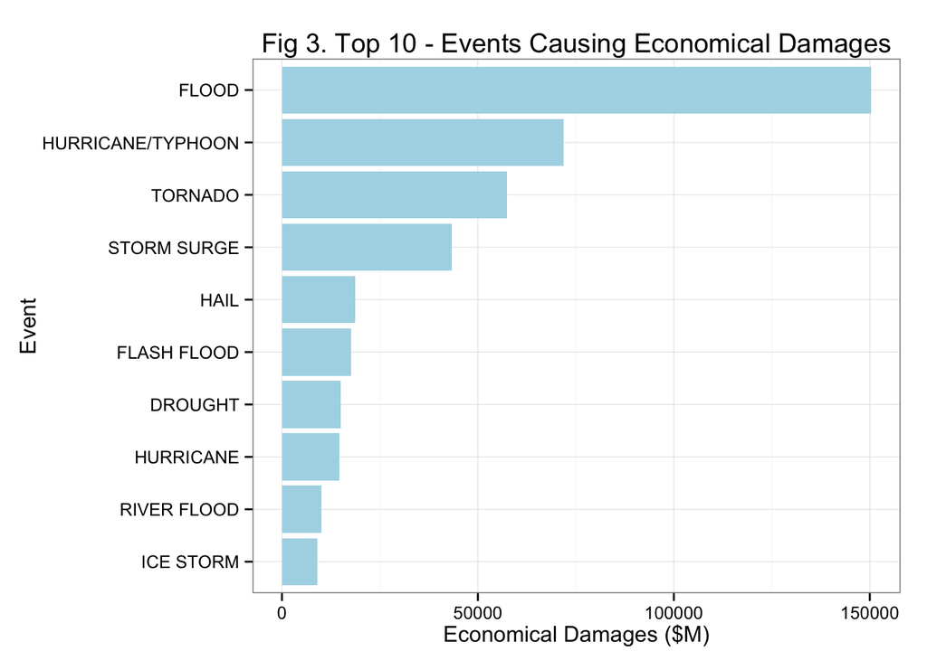

```r
### plot the results
ggplot(eco_dmg_tot_ordered[1:10, ], aes(x = reorder(evtype, economical_damage), y = economical_damage)) + theme_bw() +
    geom_bar(stat = "identity", fill = I("lightblue")) + coord_flip() +
    labs( title = "Fig 3. Top 10 - Events Causing Economical Damages",
          x = "Event",
          y = "Economical Damages ($M)" )
```